# Deliverable 1

# Imputation

```r
library(missMDA)
```

What we do with imputation is be able to eliminate all those values that may be missings, outliers or errors to turn them into values that can be realistic within our sample.

## Numeric variables

We will now do the study by variables and try to impute the necessary observations.

**Note**: we do not include MTA_tax (14), Tolls_amount(16) nor improvement_surcharge(18). We proceed to delete NA values from Total_amount because it is our target variable, so we do not impute it, but we need to have this variable without NAs.

```r
df <- df[!is.na(df$Total_amount),]

vars_quantitatives<-names(df)[c(10:13,15,24:26)]
```

```r
summary(df[,vars_quantitatives])
```

```
##  Passenger_count Trip_distance     Fare_amount        Extra
##  Min.   :1.000   Min.   : 0.010   Min.   : 1.00   Min.   :0.0000
##  1st Qu.:1.000   1st Qu.: 1.020   1st Qu.: 6.00   1st Qu.:0.0000
##  Median :1.000   Median : 1.760   Median : 9.00   Median :0.5000
##  Mean   :1.371   Mean   : 2.719   Mean   :11.47   Mean   :0.3523
##  3rd Qu.:1.000   3rd Qu.: 3.420   3rd Qu.:14.50   3rd Qu.:0.5000
##  Max.   :6.000   Max.   :27.000   Max.   :60.00   Max.   :1.0000
##  NA's   :2       NA's   :62       NA's   :30
##    Tip_amount         tlenkm         traveltime           espeed
##  Min.   : 0.000   Min.   : 0.000   Min.   :   0.000   Min.   : 3.239
##  1st Qu.: 0.000   1st Qu.: 1.609   1st Qu.:   5.767   1st Qu.:14.826
##  Median : 0.000   Median : 2.800   Median :   9.550   Median :18.613
##  Mean   : 1.029   Mean   : 4.358   Mean   :  19.863   Mean   :20.490
##  3rd Qu.: 1.700   3rd Qu.: 5.472   3rd Qu.:  16.125   3rd Qu.:23.647
##  Max.   :30.000   Max.   :69.314   Max.   :1438.183   Max.   :75.657
##  NA's   :2                                            NA's   :105
```

```r
res.imputation<-imputePCA(df[,vars_quantitatives],ncp=5)
summary(res.imputation$completeObs)
```

```
##  Passenger_count Trip_distance     Fare_amount         Extra
##  Min.   :1.000   Min.   :-0.670   Min.   :  1.00   Min.   :0.0000
##  1st Qu.:1.000   1st Qu.: 1.000   1st Qu.:  6.00   1st Qu.:0.0000
##  Median :1.000   Median : 1.760   Median :  9.00   Median :0.5000
##  Mean   :1.371   Mean   : 2.724   Mean   : 11.68   Mean   :0.3523
##  3rd Qu.:1.000   3rd Qu.: 3.400   3rd Qu.: 14.50   3rd Qu.:0.5000
##  Max.   :6.000   Max.   :40.469   Max.   :123.64   Max.   :1.0000
##    Tip_amount         tlenkm         traveltime           espeed
##  Min.   : 0.000   Min.   : 0.000   Min.   :   0.000   Min.   :-316.37
##  1st Qu.: 0.000   1st Qu.: 1.609   1st Qu.:   5.767   1st Qu.:  14.81
##  Median : 0.000   Median : 2.800   Median :   9.550   Median :  18.58
##  Mean   : 1.028   Mean   : 4.358   Mean   :  19.863   Mean   :  18.75
##  3rd Qu.: 1.700   3rd Qu.: 5.472   3rd Qu.:  16.125   3rd Qu.:  23.59
##  Max.   :30.000   Max.   :69.314   Max.   :1438.183   Max.   : 100.59
```

We proceed now to fix all the numeric variables that have errors or outliers:

#### > Trip_distance

```r
ll<-which(res.imputation$completeObs[,"Trip_distance"] < 0)
res.imputation$completeObs[ll,"Trip_distance"] <- 1
ll<-which(res.imputation$completeObs[,"Trip_distance"] > 30)
res.imputation$completeObs[ll,"Trip_distance"] <- 30
```

#### > Fare_amount

```r
ll<-which(res.imputation$completeObs[,"Fare_amount"] > 60)
res.imputation$completeObs[ll,"Fare_amount"] <- 60
```

#### > Tip_amount

```r
ll<-which(res.imputation$completeObs[,"Tip_amount"] > 17)
res.imputation$completeObs[ll,"Tip_amount"] <- 17
```

We see that we have correct data, so we proceed to create the binary factor TipIsGiven.

```r
df$TipIsGiven[(res.imputation$completeObs[,"Tip_amount"] > 0)] = "Yes"
df$TipIsGiven[(res.imputation$completeObs[,"Tip_amount"] == 0)] = "No"
df$TipIsGiven <- factor(df$TipIsGiven)
summary(df$TipIsGiven)
```

```
##   No  Yes
## 2882 1741
```

#### > tlenkm

```r
ll<-which(res.imputation$completeObs[,"tlenkm"] > 48.28)
res.imputation$completeObs[ll,"tlenkm"] <- 48.28
```

#### > traveltime

```r
ll<-which(res.imputation$completeObs[,"traveltime"] > 60)
res.imputation$completeObs[ll,"traveltime"] <- 60
```

#### > espeed

```r
ll<-which(res.imputation$completeObs[,"espeed"] < 3)
res.imputation$completeObs[ll,"espeed"] <- 3
ll<-which(res.imputation$completeObs[,"espeed"] > 55)
res.imputation$completeObs[ll,"espeed"] <- 55
```

### > Passenger_count

We decided to create categorical for this variable so we categorize it for single passengers, couple and groups (3 or more)

```r
df$passenger_groups[df$Passenger_count == 1] = "Single"
df$passenger_groups[df$Passenger_count == 2] = "Couple"
df$passenger_groups[df$Passenger_count >= 3] = "Group"
df$passenger_groups <- factor(df$passenger_groups)
```

We see the barplot in order to see the distribution of passenger per trip

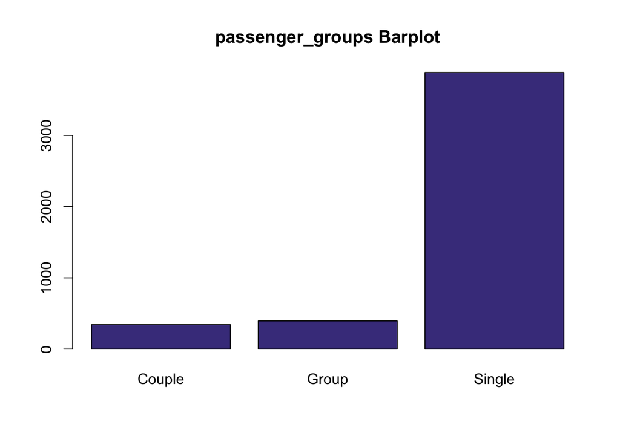

```r
barplot(table(df$passenger_groups),main="passenger_groups Barplot",col = "DarkSlateBlue")
```

### > Extra

If we execute a table, we’ll see that we have 0, 0’5 and 1 values, so we proceed to categorize this variable to see if has extra or not.

```r
table(df$Extra)
```

```
##
##    0  0.5    1
## 2128 1733  762
```

```r
df$Extra[df$Extra == 0] = 0
df$Extra[df$Extra > 0] = 1
df$Extra <- factor(df$Extra, labels =c("No","Yes"))
```

We see the barplot in order to see the distribution.

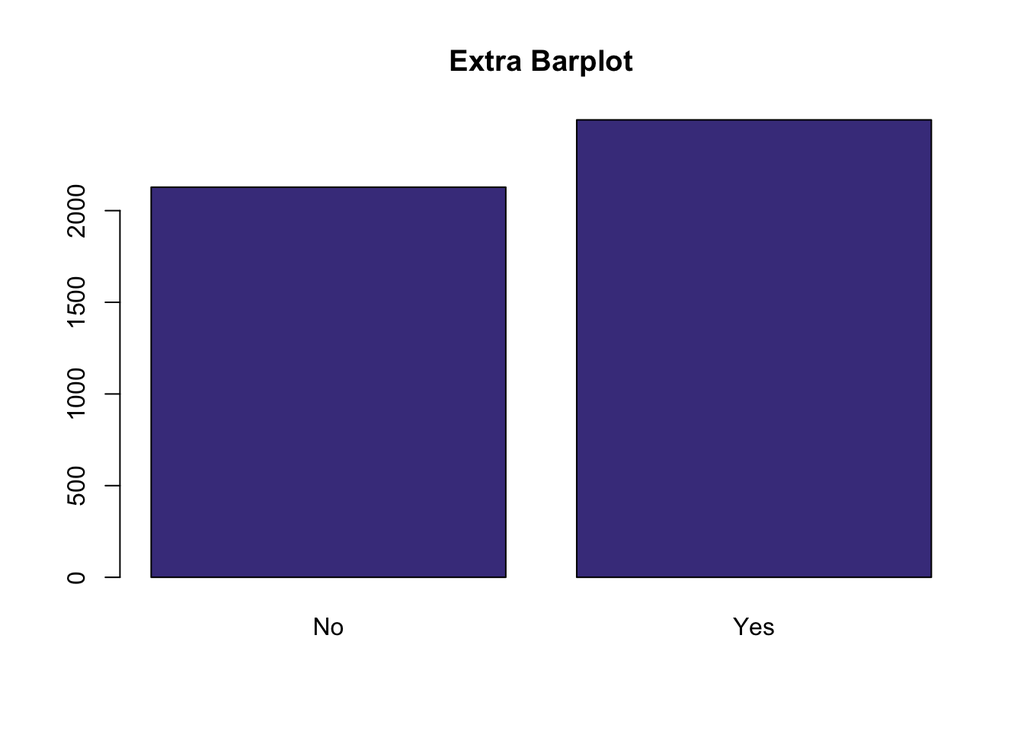

```r
barplot(table(df$Extra),main="Extra Barplot",col = "DarkSlateBlue")
```

### > MTA_tax

If we execute a summary, we’ll see that every value should be 0.5 or 0, so we proceed to categorize this variable in order to see if the tax has been paid or not.

```r
summary(df$MTA_tax)
```

```
##    Min. 1st Qu.  Median    Mean 3rd Qu.    Max.
##  0.0000  0.5000  0.5000  0.4871  0.5000  0.5000
```

```r
df$MTA_tax <- factor(df$MTA_tax, labels =c("No","Yes"))
```

We see the barplot in order to see the distribution.

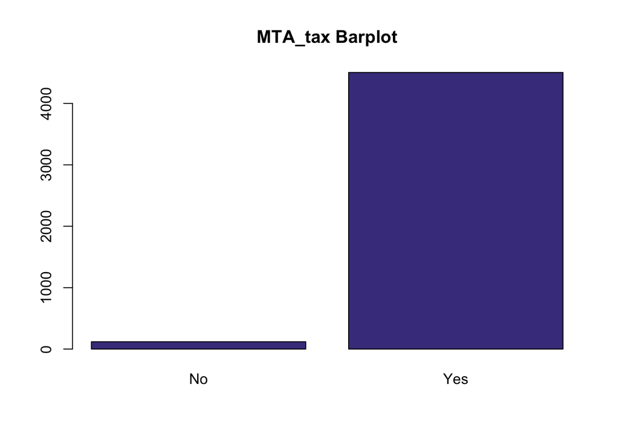

```r
barplot(table(df$MTA_tax),main="MTA_tax Barplot",col = "DarkSlateBlue")
```

### > Improvement_surcharge

If we execute a table, we’ll see that every value should be 0.3 or 0, so we proceed to categorize this variable in order to see if the surcharge has been paid or not.

```r
table(df$improvement_surcharge)
```

```
##
##    0  0.3
##  118 4505
```

```r
df$improvement_surcharge <- factor(df$improvement_surcharge)
df$improvement_surcharge <- factor(df$improvement_surcharge, labels =c("No","Yes"))
```

We see the barplot in order to see the distribution.

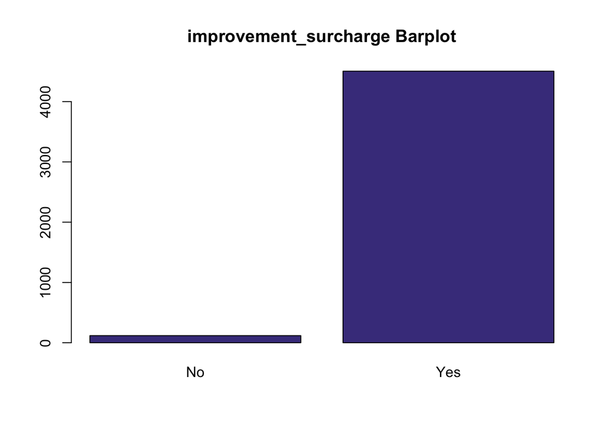

```r
barplot(table(df$improvement_surcharge),main="improvement_surcharge Barplot",col = "DarkSlateBlue")
```

We proceed to impute all NAs in our numerical variables that are stored in: `res.imputation$completeObs`

```r
#summary(res.imputation$completeObs)
df[,vars_quantitatives] <- res.imputation$completeObs
```

## Categorical variables / Factors

```r
 vars_categorical<-names(df)[c(1,4,5,20:21,23,29,35)]
 summary(df[,vars_categorical])
```

```
##               VendorID    Store_and_fwd_flag      RateCodeID
##  f.Vendor-Mobile  : 973   N:4605             Rate-1    :4496
##  f.Vendor-VeriFone:3650   Y:  18             Rate-Other: 127
##
##
##       Payment_type        Trip_type                 period
##  Credit card:2096   Street-Hail:4511   Period night    :1642
##  Cash       :2497   Dispatch   : 112   Period morning  : 542
##  No paid    :  30                      Period valley   :1260
##                                        Period afternoon:1179
##   Trip_distance_range passenger_groups
##  Long_dist  : 645     Couple: 343
##  Medium_dist: 986     Group : 395
##  Short_dist :2930     Single:3883
##  NA's       :  62     NA's  :   2
```

```r
 #nb <- estim_ncpMCA(df[, vars_categorical],ncp.max=25)
 res.input<-imputeMCA(df[,vars_categorical],ncp=10)
 summary(res.input$completeObs)
```

```
##               VendorID    Store_and_fwd_flag      RateCodeID
##  f.Vendor-Mobile  : 973   N:4605             Rate-1    :4496
##  f.Vendor-VeriFone:3650   Y:  18             Rate-Other: 127
##
##
##       Payment_type        Trip_type                 period
##  Credit card:2096   Street-Hail:4511   Period night    :1642
##  Cash       :2497   Dispatch   : 112   Period morning  : 542
##  No paid    :  30                      Period valley   :1260
##                                        Period afternoon:1179
##   Trip_distance_range passenger_groups
##  Long_dist  : 665     Couple: 343
##  Medium_dist: 986     Group : 395
##  Short_dist :2972     Single:3885
##
```

```r
# summary(res.input$completeObs)
df[,"VendorID"] <- res.input$completeObs[,"VendorID"]
df[,"Store_and_fwd_flag"] <- res.input$completeObs[,"Store_and_fwd_flag"]
df[,"RateCodeID"] <- res.input$completeObs[,"RateCodeID"]
df[,"Payment_type"] <- res.input$completeObs[,"Payment_type"]
df[,"Trip_type"] <- res.input$completeObs[,"Trip_type"]
df[,"period"] <- res.input$completeObs[,"period"]
df[,"Trip_distance_range"] <- res.input$completeObs[,"Trip_distance_range"]
df[,"passenger_groups"] <- res.input$completeObs[,"passenger_groups"]
```